# **Introductory Data Analysis of US GDP Data**

*DS 220 - Srikar Lanka*

## **Project Information:**

### Dataset Used:

This project makes use of a publically available dataset that is available on data.gov. The link to the dataset is here: https://catalog.data.gov/dataset/international-macroeconomic-data-set. The dataset is published by Steven Zahniser of the United States Economic Research Service in the Department of Agriculture. It is a set of GDP Numbers and Growth Rates for every country from 1970 - 2033.

### Reason for Choosing Dataset:

I choose this datast because I thought it would be interesting to see on paper and visualized trends of the global economics trends. Some trends we are all faimilar with, such as China overtaking the US, the rise of India, etc, but I feel it would also be helpful to take a moment to try and analyze some other trends of the global economy.

I specficially choose this dataset because it was very well organized, had data compiled for regions, and also had Growth Rates.

### Key Interested Parties:

It is my belief that these data analysis is very helpful and critical for anyone, but more importantly economics and political science majors. Economics is also king at the end of the day, and it is helpful to see any trends that may be occuring that could influence changes in power or growth/decline of a nation. It is through this analysis that key trends can be noted, followed up with, and analyzed, all of which can either influence policy decisions of many governments around the world or simply acknowledge a few of the many trends occuring. Although there are limitless possibilities in what analysis one could do in this field, I will primarily be focusing on general head-to-had analytics as these are what show the historical and future trends that effect our world.

### Importat Acknowledgment:

By the nature of how the dataset was designed, it is important to notice that this project had to make a slight modification to the datset. The original dataset had the GDP and growth-values all in the same page of the same sheet, and thus I found it would be easier to simply split the dataset into two seperate datasets for the sake of analysis through the course of this project. This dataset is available to the public under Creative Commons Attribution and thus is able to be modified, though it is important that this was stated for any interested parties.

### **Attribution:**

This work, "RealGDPValues and GrowthRates", is adapted from ["International Macroeconomic Data Set"](https://catalog.data.gov/dataset/international-macroeconomic-data-set) by Steven Zahniser, now updated by [Wendy Zeng](https://ers.usda.gov/authors/ers-staff-directory/wendy-zeng/) and [William Johnson](https://ers.usda.gov/authors/ers-staff-directory/william-johnson/) used under [CC BY 4.0](https://creativecommons.org/licenses/by/4.0/#ref-indicate-changes) "RealGDPValues and GrowthRates" is licensed under [CC BY 4.0](https://creativecommons.org/licenses/by/4.0/#ref-indicate-changes) by Srikar Lanka.

# Section 1: Imports

## Part 1: Import Packages

### Code Cell Explanation:

Before one can do any code analysis, we first have to import the relevant pacages and set the relevant configurations (as needed) as to be used throughout the project rather then importing the packages you need everytime.

I the case of this project, I will be using numpy (imported as np), matplotlib.pyplot (imported as plt), and pandas (imported as pd) as we have seen in ealier examples done through this course. On top of this, I also set the style for Matplotlib to use for graphs as "fivethirtyeight", which is a carryover from DS200 last year, but I really liked the style.

```python
import numpy as np #Import Numpy
import matplotlib.pyplot as plt #Matplotlib
import pandas as pd #Pandas

#Carryover code from DS 200 configuration of matplotlib
plt.style.use('fivethirtyeight') #Setting plot style
```

## Part 2: Import the Data

### Code Explanation:

As I previously noted, due to the fact that the dataset was very complex at first, I had split it up into two seperate data sets. This specific dataset being the GDP values from 1970-2033. The output of the code is a elementary look at the data to give you an idea of what the data is.

I read in this excel spreadsheet by first converting it to the ".csv" file format and saving it to the variable gdpValues. Due to the formatting of the original source file, I did have an issue reading in the file at-first, and thus had to change the encoding based on an internet search so it could be read. As for the formating of the original file as-well, the first 12 rows contained information about the data itself and thus was skipped using the *skiprows* argument so only the data is loaded in.

```python
gdpValues = pd.read_csv("RealGDPValues.csv", skiprows = 12, encoding='ISO-8859-1') #Read in File
gdpValues #Display
```

|  | Country | y1970 | y1971 | y1972 | y1973 | y1974 | y1975 | y1976 | y1977 | y1978 | ... | y2024 | y2025 | y2026 | y2027 | y2028 | y2029 | y2030 | y2031 | y2032 | y2033 |
| --- | --- | --- | --- | --- | --- | --- | --- | --- | --- | --- | --- | --- | --- | --- | --- | --- | --- | --- | --- | --- | --- |
| 0 | World | 18031.32 | 18886.63 | 19912.01 | 21199.60 | 21646.02 | 21799.32 | 22928.95 | 23872.10 | 24829.05 | ... | 93574.38 | 96339.12 | 99246.98 | 102149.56 | 105035.87 | 107976.13 | 110899.56 | 113783.41 | 116762.14 | 119839.41 |
| 1 | World less USA | 12842.95 | 13527.39 | 14270.94 | 15240.05 | 15718.68 | 15884.16 | 16695.07 | 17349.96 | 17945.89 | ... | 71997.94 | 74337.59 | 76703.30 | 79087.36 | 81512.44 | 84005.75 | 86473.73 | 88917.93 | 91449.07 | 94070.71 |
| 2 | United States and Canada | 5610.77 | 5798.42 | 6104.45 | 6454.60 | 6438.63 | 6433.92 | 6783.14 | 7090.28 | 7472.23 | ... | 23363.32 | 23822.74 | 24401.02 | 24954.81 | 25450.12 | 25929.82 | 26416.61 | 26890.12 | 27372.12 | 27862.76 |
| 3 | Canada | 422.41 | 439.18 | 463.38 | 495.05 | 511.29 | 518.76 | 549.26 | 568.15 | 589.07 | ... | 1786.89 | 1821.21 | 1857.33 | 1892.62 | 1926.69 | 1959.44 | 1990.79 | 2024.63 | 2059.05 | 2094.06 |
| 4 | United States | 5188.36 | 5359.23 | 5641.07 | 5959.55 | 5927.34 | 5915.16 | 6233.88 | 6522.14 | 6883.16 | ... | 21576.43 | 22001.53 | 22543.69 | 23062.19 | 23523.44 | 23970.38 | 24425.82 | 24865.49 | 25313.06 | 25768.70 |
| ... | ... | ... | ... | ... | ... | ... | ... | ... | ... | ... | ... | ... | ... | ... | ... | ... | ... | ... | ... | ... | ... |
| 227 | USMCA/8 | 5883.02 | 6080.90 | 6410.18 | 6784.37 | 6787.44 | 6802.77 | 7168.28 | 7488.49 | 7906.10 | ... | 24664.72 | 25153.86 | 25761.17 | 26344.89 | 26870.78 | 27381.74 | 27900.47 | 28408.10 | 28925.02 | 29451.37 |
| 228 | Europe and Central Asia/9 | 7308.57 | 7664.08 | 8005.14 | 8506.75 | 8720.52 | 8700.13 | 9091.03 | 9381.48 | 9700.40 | ... | 22100.40 | 22503.78 | 22898.20 | 23279.30 | 23651.64 | 24025.13 | 24393.46 | 24744.19 | 25100.99 | 25464.03 |
| 229 | Middle East and North Africa/10 | 656.43 | 726.18 | 825.21 | 901.50 | 976.96 | 970.15 | 1095.63 | 1139.91 | 1110.88 | ... | 4939.36 | 5098.38 | 5243.96 | 5395.11 | 5550.94 | 5707.07 | 5863.06 | 6029.28 | 6200.49 | 6376.84 |
| 230 | Other Southeast Asia outlook/11 | 125.43 | 132.59 | 139.47 | 150.81 | 157.53 | 164.17 | 180.12 | 195.00 | 207.45 | ... | 1681.35 | 1765.17 | 1850.05 | 1935.66 | 2022.98 | 2112.44 | 2203.41 | 2297.07 | 2394.93 | 2497.20 |
| 231 | Other South America outlook/12 | 168.01 | 177.61 | 183.69 | 189.40 | 200.16 | 200.82 | 208.02 | 216.86 | 226.97 | ... | 1035.45 | 1067.13 | 1103.02 | 1140.29 | 1178.78 | 1218.50 | 1259.49 | 1301.15 | 1344.20 | 1388.68 |

232 rows × 65 columns

Similar story as above, this time I loaded in the newly seperated Growth Rates. For the same reason as above I had to change the encoding again to read in the file, though here *skiprows* was not needed. Once again, a brief look at the data is present for your viewing pleasure below.

```python
growthRates = pd.read_csv("GrwothRate.csv", encoding='ISO-8859-1') #Read in File
growthRates #Display
```

|  | Country | g1971 | g1972 | g1973 | g1974 | g1975 | g1976 | g1977 | g1978 | g1979 | ... | g2024 | g2025 | g2026 | g2027 | g2028 | g2029 | g2030 | g2031 | g2032 | g2033 |
| --- | --- | --- | --- | --- | --- | --- | --- | --- | --- | --- | --- | --- | --- | --- | --- | --- | --- | --- | --- | --- | --- |
| 0 | World | 4.74 | 5.43 | 6.47 | 2.11 | 0.71 | 5.18 | 4.11 | 4.01 | 4.42 | ... | 2.66 | 2.95 | 3.02 | 2.92 | 2.83 | 2.80 | 2.71 | 2.60 | 2.62 | 2.64 |
| 1 | World less USA | 5.33 | 5.50 | 6.79 | 3.14 | 1.05 | 5.11 | 3.92 | 3.43 | 4.90 | ... | 3.10 | 3.25 | 3.18 | 3.11 | 3.07 | 3.06 | 2.94 | 2.83 | 2.85 | 2.87 |
| 2 | United States and Canada | 3.34 | 5.28 | 5.74 | -0.25 | -0.07 | 5.43 | 4.53 | 5.39 | 3.21 | ... | 1.27 | 1.97 | 2.43 | 2.27 | 1.98 | 1.88 | 1.88 | 1.79 | 1.79 | 1.79 |
| 3 | Canada | 3.97 | 5.51 | 6.84 | 3.28 | 1.46 | 5.88 | 3.44 | 3.68 | 3.71 | ... | 1.65 | 1.92 | 1.98 | 1.90 | 1.80 | 1.70 | 1.60 | 1.70 | 1.70 | 1.70 |
| 4 | United States | 3.29 | 5.26 | 5.65 | -0.54 | -0.21 | 5.39 | 4.62 | 5.54 | 3.17 | ... | 1.24 | 1.97 | 2.46 | 2.30 | 2.00 | 1.90 | 1.90 | 1.80 | 1.80 | 1.80 |
| ... | ... | ... | ... | ... | ... | ... | ... | ... | ... | ... | ... | ... | ... | ... | ... | ... | ... | ... | ... | ... | ... |
| 227 | USMCA/8 | 3.36 | 5.41 | 5.84 | 0.05 | 0.23 | 5.37 | 4.47 | 5.58 | 3.57 | ... | 1.31 | 1.98 | 2.41 | 2.27 | 2.00 | 1.90 | 1.89 | 1.82 | 1.82 | 1.82 |
| 228 | Europe and Central Asia/9 | 4.86 | 4.45 | 6.27 | 2.51 | -0.23 | 4.49 | 3.19 | 3.40 | 3.76 | ... | 1.31 | 1.83 | 1.75 | 1.66 | 1.60 | 1.58 | 1.53 | 1.44 | 1.44 | 1.45 |
| 229 | Middle East and North Africa/10 | 10.63 | 13.64 | 9.25 | 8.37 | -0.70 | 12.93 | 4.04 | -2.55 | 10.65 | ... | 3.10 | 3.22 | 2.86 | 2.88 | 2.89 | 2.81 | 2.73 | 2.84 | 2.84 | 2.84 |
| 230 | Other Southeast Asia outlook/11 | 5.71 | 5.19 | 8.13 | 4.46 | 4.21 | 9.72 | 8.26 | 6.39 | 6.35 | ... | 5.08 | 4.99 | 4.81 | 4.63 | 4.51 | 4.42 | 4.31 | 4.25 | 4.26 | 4.27 |
| 231 | Other South America outlook/12 | 5.72 | 3.42 | 3.11 | 5.68 | 0.33 | 3.58 | 4.25 | 4.66 | 5.71 | ... | 2.36 | 3.06 | 3.36 | 3.38 | 3.38 | 3.37 | 3.36 | 3.31 | 3.31 | 3.31 |

232 rows × 64 columns

### Code Takeaways:

From above, we see that we now see a dataset split into two seperate datasets, one called gdpValues which contains the GDP values of countries from 1970 to 2033, and growthRates which contains the Growth Rates of countries from 1971 to 2033.

We also see that it is not just countries that are present, but there are certain groupings such as the World, the World wothout the US, US and Canada, etc. This is something to note as it may present a challenge for certain queries and thus may need to be dealt with.

## Part 3: Understanding Basic Data Details

Before we conduct analysis and try to answer our questions, we should first get a elementary understanding of the data we are looking. Below we will use various pandas commands that are able to summarize the general trends of note in our data.

### Code Explanation and Items of Note:

Here, we will make use of the *describe()* method for both gdpValues and growthRates. This method returns various statistical information such as count, mean, std, min, and max, for each column. In our case, the columns are the years from 1970 to 2033 for GDP Values, and 1971 to 2033 for Growth Rates.

```python
gdpValues.describe() #Describe Method
```

|  | y1970 | y1971 | y1972 | y1973 | y1974 | y1975 | y1976 | y1977 | y1978 | y1979 | ... | y2024 | y2025 | y2026 | y2027 | y2028 | y2029 | y2030 | y2031 | y2032 | y2033 |
| --- | --- | --- | --- | --- | --- | --- | --- | --- | --- | --- | --- | --- | --- | --- | --- | --- | --- | --- | --- | --- | --- |
| count | 211.000000 | 212.000000 | 212.000000 | 213.000000 | 214.000000 | 217.000000 | 217.000000 | 221.000000 | 221.000000 | 227.000000 | ... | 232.000000 | 232.000000 | 232.000000 | 232.000000 | 232.000000 | 232.000000 | 232.000000 | 232.000000 | 232.000000 | 232.000000 |
| mean | 641.121706 | 669.197783 | 705.205189 | 747.877840 | 762.089159 | 757.072995 | 795.432995 | 812.543303 | 844.673575 | 859.890881 | ... | 3218.189828 | 3318.463491 | 3422.292716 | 3526.183233 | 3630.335000 | 3736.937845 | 3842.417371 | 3946.274353 | 4053.684138 | 4164.788147 |
| std | 2188.287523 | 2285.712304 | 2408.168917 | 2558.434093 | 2604.155624 | 2597.956322 | 2728.685657 | 2811.732438 | 2922.881874 | 3011.265122 | ... | 10511.217947 | 10833.250929 | 11168.903642 | 11505.371054 | 11842.906464 | 12189.233579 | 12532.205670 | 12870.117982 | 13220.335250 | 13583.384589 |
| min | 0.080000 | 0.090000 | 0.090000 | 0.090000 | 0.100000 | 0.100000 | 0.100000 | 0.130000 | 0.130000 | 0.130000 | ... | 0.410000 | 0.420000 | 0.440000 | 0.450000 | 0.470000 | 0.480000 | 0.500000 | 0.510000 | 0.520000 | 0.530000 |
| 25% | 4.470000 | 4.797500 | 4.900000 | 5.140000 | 5.045000 | 5.010000 | 5.370000 | 5.540000 | 5.320000 | 5.720000 | ... | 18.472500 | 19.612500 | 20.577500 | 21.550000 | 22.510000 | 23.597500 | 24.732500 | 25.702500 | 26.507500 | 27.430000 |
| 50% | 23.120000 | 24.520000 | 25.435000 | 27.220000 | 27.950000 | 27.720000 | 29.250000 | 27.860000 | 28.570000 | 29.310000 | ... | 98.465000 | 101.400000 | 104.625000 | 108.670000 | 114.585000 | 118.740000 | 122.025000 | 125.730000 | 130.075000 | 134.360000 |
| 75% | 186.290000 | 192.592500 | 202.825000 | 214.110000 | 222.207500 | 222.850000 | 230.750000 | 231.130000 | 230.600000 | 232.175000 | ... | 772.637500 | 786.005000 | 795.477500 | 805.835000 | 817.767500 | 830.317500 | 843.085000 | 864.742500 | 892.847500 | 921.917500 |
| max | 18031.320000 | 18886.630000 | 19912.010000 | 21199.600000 | 21646.020000 | 21799.320000 | 22928.950000 | 23872.100000 | 24829.050000 | 25925.970000 | ... | 93574.380000 | 96339.120000 | 99246.980000 | 102149.560000 | 105035.870000 | 107976.130000 | 110899.560000 | 113783.410000 | 116762.140000 | 119839.410000 |

8 rows × 64 columns

```python
growthRates.describe() #Describe Method
```

|  | g1971 | g1972 | g1973 | g1974 | g1975 | g1976 | g1977 | g1978 | g1979 | g1980 | ... | g2024 | g2025 | g2026 | g2027 | g2028 | g2029 | g2030 | g2031 | g2032 | g2033 |
| --- | --- | --- | --- | --- | --- | --- | --- | --- | --- | --- | --- | --- | --- | --- | --- | --- | --- | --- | --- | --- | --- |
| count | 211.000000 | 212.000000 | 212.000000 | 213.000000 | 214.000000 | 217.000000 | 217.000000 | 221.000000 | 221.000000 | 227.000000 | ... | 232.000000 | 232.000000 | 232.000000 | 232.000000 | 232.000000 | 232.000000 | 232.000000 | 232.000000 | 232.000000 | 232.000000 |
| mean | 5.356209 | 5.372075 | 5.095472 | 4.662394 | 2.400514 | 5.729954 | 4.868341 | 4.382217 | 5.542624 | 3.241894 | ... | 3.820086 | 3.724267 | 3.561595 | 3.331422 | 3.218362 | 3.143664 | 3.063879 | 2.974526 | 2.976121 | 2.977586 |
| std | 4.695529 | 5.343026 | 5.052970 | 5.002168 | 5.902999 | 7.079981 | 7.158598 | 5.254001 | 8.948060 | 6.060921 | ... | 3.923886 | 2.155947 | 2.070884 | 1.416290 | 1.356758 | 1.322220 | 1.285248 | 1.258784 | 1.259166 | 1.259594 |
| min | -11.330000 | -13.970000 | -17.050000 | -16.750000 | -30.300000 | -56.990000 | -12.580000 | -24.050000 | -26.480000 | -27.530000 | ... | -1.000000 | 0.330000 | 0.920000 | 0.900000 | 0.900000 | 0.800000 | 0.700000 | 0.600000 | 0.600000 | 0.600000 |
| 25% | 3.090000 | 2.667500 | 3.090000 | 2.510000 | -0.115000 | 3.090000 | 2.440000 | 2.040000 | 3.090000 | 0.955000 | ... | 2.257500 | 2.497500 | 2.332500 | 2.285000 | 2.272500 | 2.200000 | 2.100000 | 2.100000 | 2.100000 | 2.100000 |
| 50% | 4.820000 | 4.730000 | 5.360000 | 4.260000 | 2.650000 | 5.120000 | 4.040000 | 4.410000 | 4.290000 | 3.090000 | ... | 3.100000 | 3.295000 | 3.075000 | 3.035000 | 2.900000 | 2.900000 | 2.845000 | 2.800000 | 2.800000 | 2.800000 |
| 75% | 6.615000 | 6.785000 | 7.665000 | 6.210000 | 5.377500 | 7.930000 | 6.900000 | 6.910000 | 7.200000 | 5.895000 | ... | 4.477500 | 4.480000 | 4.432500 | 4.225000 | 4.012500 | 3.977500 | 3.800000 | 3.625000 | 3.642500 | 3.652500 |
| max | 31.840000 | 27.420000 | 26.400000 | 39.490000 | 24.430000 | 35.630000 | 83.280000 | 22.000000 | 87.610000 | 24.750000 | ... | 43.300000 | 20.300000 | 24.000000 | 8.000000 | 7.700000 | 7.400000 | 7.300000 | 7.300000 | 7.300000 | 7.300000 |

8 rows × 63 columns

### Code Explanation and Items of Note:

Here we will make use of the *info* method, which returns every column and the type that it is. We will apply it to both gdpValues and GrowthRates.

**Key Notes** Here, there is nothhing neccesarily unexpected other then the key point of interest being that the values we are interested in are all of the **float** integer type. Other then that the data is expected, with each having a County object (which is assumbly a string object) as one of the columns and then the rest being countries. Another important thing to note here that is good to note is that gdpValues has a extra column compared to GrowthRates, that being 1970. THis is important to note.

```python
gdpValues.info() #Info Method
```

```
<class 'pandas.core.frame.DataFrame'>
RangeIndex: 232 entries, 0 to 231
Data columns (total 65 columns):
 #   Column   Non-Null Count  Dtype
---  ------   --------------  -----
 0   Country  232 non-null    object
 1   y1970    211 non-null    float64
 2   y1971    212 non-null    float64
 3   y1972    212 non-null    float64
 4   y1973    213 non-null    float64
 5   y1974    214 non-null    float64
 6   y1975    217 non-null    float64
 7   y1976    217 non-null    float64
 8   y1977    221 non-null    float64
 9   y1978    221 non-null    float64
```

[output cut: 57 more lines]

```python
growthRates.info() #Info Method
```

```
<class 'pandas.core.frame.DataFrame'>
RangeIndex: 232 entries, 0 to 231
Data columns (total 64 columns):
 #   Column   Non-Null Count  Dtype
---  ------   --------------  -----
 0   Country  232 non-null    object
 1   g1971    211 non-null    float64
 2   g1972    212 non-null    float64
 3   g1973    212 non-null    float64
 4   g1974    213 non-null    float64
 5   g1975    214 non-null    float64
 6   g1976    217 non-null    float64
 7   g1977    217 non-null    float64
 8   g1978    221 non-null    float64
 9   g1979    221 non-null    float64
```

[output cut: 56 more lines]

### Code Explanation and Items of Note:

Finally, here, we make use of the *shape* method on both gdpValues and growthRates. This returns the ammount of rows and columns that are present in each data table.

**Key Notes** In the context of above, this query is fairly unremarkable. All it does is confirm what we established above that both datsets make use of the same countries or rows, but gdpValues has a extra column in the form of 1970.

```python
gdpValues.shape #Shape Method
```

```
(232, 65)
```

```python
growthRates.shape #Shape Method
```

```
(232, 64)
```

# Section 2: Data Pre-Processing

Now that we have established an elementary understanding of the dataset, we are now able to get going on data analysis. That being said, there is still one critical step that we need to handle in-order to properly be able to do data analysis. That step being pre-processing, a step in-which we fill in any holes in the code and patch any issues that may make data analysis difficult.

### Code Explanation and Items of Note:

As mentioned above, this dataset contains data for regions as-well-as organizations such as BRICS. This is great data and I will definetly make use of it later, but for the questions I have to start the problem off they will only primarily get in the way. For that reason, I have isolated every row that contains a region or organization and will remove them by passing in an array of these values to the *drop* method of the dataframe. This will remove these rows and will make for a more simplified data analysis expirience.

**Rows of Organizations/Regions Isolated:**

> 0, 1, 2, 5, 7, 29, 32, 43, 44, 45, 46, 47, 63, 77, 78, 82, 87, 90, 101, 102, 103, 104, 105, 111, 114, 122, 126, 130, 135, 138, 146, 147, 152, 163, 164, 167, 171, 174, 189, 220, 221, 222, 223, 224, 225, 226, 227, 228, 229, 230, 231

```python
gdpValues = gdpValues.drop([0, 1, 2, 5, 7, 29, 32, 43, 44, 45, 46, 47, 63, 77, 78, 82, 87, 90, 101, 102, 103, 104, 105, 111, 114, 122, 126, 130, 135, 138, 146, 147, 152, 163, 164, 167, 171, 174, 189, 220, 221, 222, 223, 224, 225, 226, 227, 228, 229, 230, 231])
gdpValues #Drop Unncessary Colums and Display
```

|  | Country | y1970 | y1971 | y1972 | y1973 | y1974 | y1975 | y1976 | y1977 | y1978 | ... | y2024 | y2025 | y2026 | y2027 | y2028 | y2029 | y2030 | y2031 | y2032 | y2033 |
| --- | --- | --- | --- | --- | --- | --- | --- | --- | --- | --- | --- | --- | --- | --- | --- | --- | --- | --- | --- | --- | --- |
| 3 | Canada | 422.41 | 439.18 | 463.38 | 495.05 | 511.29 | 518.76 | 549.26 | 568.15 | 589.07 | ... | 1786.89 | 1821.21 | 1857.33 | 1892.62 | 1926.69 | 1959.44 | 1990.79 | 2024.63 | 2059.05 | 2094.06 |
| 4 | United States | 5188.36 | 5359.23 | 5641.07 | 5959.55 | 5927.34 | 5915.16 | 6233.88 | 6522.14 | 6883.16 | ... | 21576.43 | 22001.53 | 22543.69 | 23062.19 | 23523.44 | 23970.38 | 24425.82 | 24865.49 | 25313.06 | 25768.70 |
| 6 | Mexico | 272.24 | 282.49 | 305.73 | 329.76 | 348.81 | 368.85 | 385.15 | 398.20 | 433.87 | ... | 1301.40 | 1331.12 | 1360.15 | 1390.08 | 1420.66 | 1451.91 | 1483.86 | 1517.98 | 1552.90 | 1588.62 |
| 8 | Antigua and Barbuda | NaN | NaN | NaN | NaN | NaN | NaN | NaN | 0.35 | 0.36 | ... | 1.64 | 1.68 | 1.72 | 1.77 | 1.82 | 1.86 | 1.91 | 1.96 | 2.01 | 2.06 |
| 9 | Bahamas | 4.87 | 4.95 | 4.78 | 5.14 | 4.28 | 3.64 | 3.83 | 4.18 | 4.78 | ... | 12.26 | 12.55 | 12.78 | 13.01 | 13.23 | 13.45 | 13.65 | 13.85 | 14.06 | 14.27 |
| ... | ... | ... | ... | ... | ... | ... | ... | ... | ... | ... | ... | ... | ... | ... | ... | ... | ... | ... | ... | ... | ... |
| 215 | São Tomé and Principe | 0.08 | 0.09 | 0.09 | 0.09 | 0.10 | 0.10 | 0.10 | 0.13 | 0.13 | ... | 0.41 | 0.42 | 0.44 | 0.45 | 0.47 | 0.48 | 0.50 | 0.51 | 0.53 | 0.55 |
| 216 | Tanzania | 7.35 | 7.66 | 8.17 | 8.42 | 8.63 | 9.14 | 9.73 | 9.77 | 9.89 | ... | 76.88 | 81.15 | 85.70 | 90.59 | 95.75 | 101.21 | 106.98 | 113.18 | 119.75 | 126.70 |
| 217 | Uganda | 5.30 | 5.44 | 5.44 | 5.44 | 5.44 | 5.37 | 5.37 | 5.44 | 5.22 | ... | 48.57 | 51.58 | 55.29 | 59.05 | 62.83 | 66.60 | 70.33 | 73.85 | 77.54 | 81.42 |
| 218 | Zambia | 5.39 | 5.38 | 5.88 | 5.82 | 6.19 | 6.05 | 6.43 | 6.14 | 6.17 | ... | 27.57 | 28.73 | 29.88 | 31.08 | 32.32 | 33.62 | 34.96 | 36.36 | 37.81 | 39.33 |
| 219 | Zimbabwe | 8.08 | 8.80 | 9.54 | 9.79 | 10.43 | 10.23 | 10.28 | 9.58 | 9.32 | ... | 22.86 | 23.73 | 24.62 | 25.50 | 26.42 | 27.35 | 28.28 | 29.24 | 30.23 | 31.26 |

181 rows × 65 columns

```python
growthRates = growthRates.drop([0, 1, 2, 5, 7, 29, 32, 43, 44, 45, 46, 47, 63, 77, 78, 82, 87, 90, 101, 102, 103, 104, 105, 111, 114, 122, 126, 130, 135, 138, 146, 147, 152, 163, 164, 167, 171, 174, 189, 220, 221, 222, 223, 224, 225, 226, 227, 228, 229, 230, 231])
growthRates #Drop Unncessary Colums and Display
```

|  | Country | g1971 | g1972 | g1973 | g1974 | g1975 | g1976 | g1977 | g1978 | g1979 | ... | g2024 | g2025 | g2026 | g2027 | g2028 | g2029 | g2030 | g2031 | g2032 | g2033 |
| --- | --- | --- | --- | --- | --- | --- | --- | --- | --- | --- | --- | --- | --- | --- | --- | --- | --- | --- | --- | --- | --- |
| 3 | Canada | 3.97 | 5.51 | 6.84 | 3.28 | 1.46 | 5.88 | 3.44 | 3.68 | 3.71 | ... | 1.65 | 1.92 | 1.98 | 1.9 | 1.8 | 1.7 | 1.6 | 1.7 | 1.7 | 1.7 |
| 4 | United States | 3.29 | 5.26 | 5.65 | -0.54 | -0.21 | 5.39 | 4.62 | 5.54 | 3.17 | ... | 1.24 | 1.97 | 2.46 | 2.3 | 2.0 | 1.9 | 1.9 | 1.8 | 1.8 | 1.8 |
| 6 | Mexico | 3.76 | 8.23 | 7.86 | 5.78 | 5.74 | 4.42 | 3.39 | 8.96 | 9.70 | ... | 1.99 | 2.28 | 2.18 | 2.2 | 2.2 | 2.2 | 2.2 | 2.3 | 2.3 | 2.3 |
| 8 | Antigua and Barbuda | NaN | NaN | NaN | NaN | NaN | NaN | NaN | 4.38 | 8.08 | ... | 2.89 | 2.56 | 2.57 | 2.6 | 2.6 | 2.6 | 2.5 | 2.5 | 2.5 | 2.5 |
| 9 | Bahamas | 1.63 | -3.50 | 7.57 | -16.75 | -14.80 | 5.19 | 9.15 | 14.18 | 26.14 | ... | 2.92 | 2.35 | 1.87 | 1.8 | 1.7 | 1.6 | 1.5 | 1.5 | 1.5 | 1.5 |
| ... | ... | ... | ... | ... | ... | ... | ... | ... | ... | ... | ... | ... | ... | ... | ... | ... | ... | ... | ... | ... | ... |
| 215 | São Tomé and Principe | 5.38 | 2.29 | 1.59 | 5.68 | 5.38 | 1.64 | 23.42 | 2.90 | 16.34 | ... | 3.30 | 3.40 | 3.39 | 3.4 | 3.4 | 3.3 | 3.3 | 3.3 | 3.3 | 3.3 |
| 216 | Tanzania | 4.18 | 6.72 | 3.06 | 2.50 | 5.91 | 6.39 | 0.40 | 1.21 | 3.35 | ... | 5.50 | 5.55 | 5.61 | 5.7 | 5.7 | 5.7 | 5.7 | 5.8 | 5.8 | 5.8 |
| 217 | Uganda | 2.74 | 0.00 | 0.00 | 0.00 | -1.33 | 0.00 | 1.35 | -4.00 | -12.50 | ... | 5.70 | 6.20 | 7.20 | 6.8 | 6.4 | 6.0 | 5.6 | 5.0 | 5.0 | 5.0 |
| 218 | Zambia | -0.09 | 9.21 | -0.96 | 6.43 | -2.27 | 6.22 | -4.56 | 0.55 | -3.02 | ... | 3.70 | 4.20 | 4.00 | 4.0 | 4.0 | 4.0 | 4.0 | 4.0 | 4.0 | 4.0 |
| 219 | Zimbabwe | 8.92 | 8.33 | 2.60 | 6.63 | -1.93 | 0.46 | -6.86 | -2.71 | 3.30 | ... | 3.70 | 3.80 | 3.72 | 3.6 | 3.6 | 3.5 | 3.4 | 3.4 | 3.4 | 3.4 |

181 rows × 64 columns

### Code Explanation and Items of Note:

All is well and dandy, the regions and organizations are dropped and we can now begin. Except, look above at **Antigua and Barbuda.** It appears they either did not have data at the time or did not yet exist. Eitherway, N/A values are not good and need to be delt with. To that end, there is no one good way to deal with the N/A values, and all options were debated over. The issue is mean, median, mode, etc. are out of the picture as it would skew the data, making them not usable in this case. Another option would be to drop the effected rows/columns, but that would also not be a option since it would effect the sizes of each row and would take away from analysis. For that reason, all problems below will be treated as statistics since 1970/1971 unless otherwise stated, and countries that do not have values since then will have a 0 in-place of the N/A. This is done with the *fillna* method of dataframes, with the argument *0* passed in as the value we want filled in. We will have to do this for both gdpValues and growthRates.

```python
gdpValues = gdpValues.fillna(0)
gdpValues #Fill NAs with 0 and Display
```

|  | Country | y1970 | y1971 | y1972 | y1973 | y1974 | y1975 | y1976 | y1977 | y1978 | ... | y2024 | y2025 | y2026 | y2027 | y2028 | y2029 | y2030 | y2031 | y2032 | y2033 |
| --- | --- | --- | --- | --- | --- | --- | --- | --- | --- | --- | --- | --- | --- | --- | --- | --- | --- | --- | --- | --- | --- |
| 3 | Canada | 422.41 | 439.18 | 463.38 | 495.05 | 511.29 | 518.76 | 549.26 | 568.15 | 589.07 | ... | 1786.89 | 1821.21 | 1857.33 | 1892.62 | 1926.69 | 1959.44 | 1990.79 | 2024.63 | 2059.05 | 2094.06 |
| 4 | United States | 5188.36 | 5359.23 | 5641.07 | 5959.55 | 5927.34 | 5915.16 | 6233.88 | 6522.14 | 6883.16 | ... | 21576.43 | 22001.53 | 22543.69 | 23062.19 | 23523.44 | 23970.38 | 24425.82 | 24865.49 | 25313.06 | 25768.70 |
| 6 | Mexico | 272.24 | 282.49 | 305.73 | 329.76 | 348.81 | 368.85 | 385.15 | 398.20 | 433.87 | ... | 1301.40 | 1331.12 | 1360.15 | 1390.08 | 1420.66 | 1451.91 | 1483.86 | 1517.98 | 1552.90 | 1588.62 |
| 8 | Antigua and Barbuda | 0.00 | 0.00 | 0.00 | 0.00 | 0.00 | 0.00 | 0.00 | 0.35 | 0.36 | ... | 1.64 | 1.68 | 1.72 | 1.77 | 1.82 | 1.86 | 1.91 | 1.96 | 2.01 | 2.06 |
| 9 | Bahamas | 4.87 | 4.95 | 4.78 | 5.14 | 4.28 | 3.64 | 3.83 | 4.18 | 4.78 | ... | 12.26 | 12.55 | 12.78 | 13.01 | 13.23 | 13.45 | 13.65 | 13.85 | 14.06 | 14.27 |
| ... | ... | ... | ... | ... | ... | ... | ... | ... | ... | ... | ... | ... | ... | ... | ... | ... | ... | ... | ... | ... | ... |
| 215 | São Tomé and Principe | 0.08 | 0.09 | 0.09 | 0.09 | 0.10 | 0.10 | 0.10 | 0.13 | 0.13 | ... | 0.41 | 0.42 | 0.44 | 0.45 | 0.47 | 0.48 | 0.50 | 0.51 | 0.53 | 0.55 |
| 216 | Tanzania | 7.35 | 7.66 | 8.17 | 8.42 | 8.63 | 9.14 | 9.73 | 9.77 | 9.89 | ... | 76.88 | 81.15 | 85.70 | 90.59 | 95.75 | 101.21 | 106.98 | 113.18 | 119.75 | 126.70 |
| 217 | Uganda | 5.30 | 5.44 | 5.44 | 5.44 | 5.44 | 5.37 | 5.37 | 5.44 | 5.22 | ... | 48.57 | 51.58 | 55.29 | 59.05 | 62.83 | 66.60 | 70.33 | 73.85 | 77.54 | 81.42 |
| 218 | Zambia | 5.39 | 5.38 | 5.88 | 5.82 | 6.19 | 6.05 | 6.43 | 6.14 | 6.17 | ... | 27.57 | 28.73 | 29.88 | 31.08 | 32.32 | 33.62 | 34.96 | 36.36 | 37.81 | 39.33 |
| 219 | Zimbabwe | 8.08 | 8.80 | 9.54 | 9.79 | 10.43 | 10.23 | 10.28 | 9.58 | 9.32 | ... | 22.86 | 23.73 | 24.62 | 25.50 | 26.42 | 27.35 | 28.28 | 29.24 | 30.23 | 31.26 |

181 rows × 65 columns

```python
growthRates = growthRates.fillna(0)
growthRates #Fill NAs with 0 and Display
```

|  | Country | g1971 | g1972 | g1973 | g1974 | g1975 | g1976 | g1977 | g1978 | g1979 | ... | g2024 | g2025 | g2026 | g2027 | g2028 | g2029 | g2030 | g2031 | g2032 | g2033 |
| --- | --- | --- | --- | --- | --- | --- | --- | --- | --- | --- | --- | --- | --- | --- | --- | --- | --- | --- | --- | --- | --- |
| 3 | Canada | 3.97 | 5.51 | 6.84 | 3.28 | 1.46 | 5.88 | 3.44 | 3.68 | 3.71 | ... | 1.65 | 1.92 | 1.98 | 1.9 | 1.8 | 1.7 | 1.6 | 1.7 | 1.7 | 1.7 |
| 4 | United States | 3.29 | 5.26 | 5.65 | -0.54 | -0.21 | 5.39 | 4.62 | 5.54 | 3.17 | ... | 1.24 | 1.97 | 2.46 | 2.3 | 2.0 | 1.9 | 1.9 | 1.8 | 1.8 | 1.8 |
| 6 | Mexico | 3.76 | 8.23 | 7.86 | 5.78 | 5.74 | 4.42 | 3.39 | 8.96 | 9.70 | ... | 1.99 | 2.28 | 2.18 | 2.2 | 2.2 | 2.2 | 2.2 | 2.3 | 2.3 | 2.3 |
| 8 | Antigua and Barbuda | 0.00 | 0.00 | 0.00 | 0.00 | 0.00 | 0.00 | 0.00 | 4.38 | 8.08 | ... | 2.89 | 2.56 | 2.57 | 2.6 | 2.6 | 2.6 | 2.5 | 2.5 | 2.5 | 2.5 |
| 9 | Bahamas | 1.63 | -3.50 | 7.57 | -16.75 | -14.80 | 5.19 | 9.15 | 14.18 | 26.14 | ... | 2.92 | 2.35 | 1.87 | 1.8 | 1.7 | 1.6 | 1.5 | 1.5 | 1.5 | 1.5 |
| ... | ... | ... | ... | ... | ... | ... | ... | ... | ... | ... | ... | ... | ... | ... | ... | ... | ... | ... | ... | ... | ... |
| 215 | São Tomé and Principe | 5.38 | 2.29 | 1.59 | 5.68 | 5.38 | 1.64 | 23.42 | 2.90 | 16.34 | ... | 3.30 | 3.40 | 3.39 | 3.4 | 3.4 | 3.3 | 3.3 | 3.3 | 3.3 | 3.3 |
| 216 | Tanzania | 4.18 | 6.72 | 3.06 | 2.50 | 5.91 | 6.39 | 0.40 | 1.21 | 3.35 | ... | 5.50 | 5.55 | 5.61 | 5.7 | 5.7 | 5.7 | 5.7 | 5.8 | 5.8 | 5.8 |
| 217 | Uganda | 2.74 | 0.00 | 0.00 | 0.00 | -1.33 | 0.00 | 1.35 | -4.00 | -12.50 | ... | 5.70 | 6.20 | 7.20 | 6.8 | 6.4 | 6.0 | 5.6 | 5.0 | 5.0 | 5.0 |
| 218 | Zambia | -0.09 | 9.21 | -0.96 | 6.43 | -2.27 | 6.22 | -4.56 | 0.55 | -3.02 | ... | 3.70 | 4.20 | 4.00 | 4.0 | 4.0 | 4.0 | 4.0 | 4.0 | 4.0 | 4.0 |
| 219 | Zimbabwe | 8.92 | 8.33 | 2.60 | 6.63 | -1.93 | 0.46 | -6.86 | -2.71 | 3.30 | ... | 3.70 | 3.80 | 3.72 | 3.6 | 3.6 | 3.5 | 3.4 | 3.4 | 3.4 | 3.4 |

181 rows × 64 columns

# Section 3: Data Analysis

Now, after getting to know the data and doing some much needed cleanup, we can finally get started on our ten questions. These questions all vary in area of interest and what they hope to answer. Each question will have a section or two explaining the code and any key notes involved in the writing of the code or decisions made and then key-takeaways from the code. I appreciate you taking time to review this GitHub project. Have a good day and I hope you enjoy!

**Questions to be Answered**

- Question 1: What are the top 5 countries by GDP in 2023 and 2033?
- Question 2: When are India and China set to overtake traditonal powers such as Germany and the USA in GDP?
- Question 3: What are the top 5 and lowest 5 country GDPs each year from 1970 - 2033?
- Question 4: What are the Highest and Lowest Changes in GDP from 1970 to 2033
- Question 5: Is the saying that when the US catches a cold the world sneezes true?
- Question 6: Was the new century growth of China really that unprecedented?
- Question 7: How do multiple countries of choice compare in GDP or Growth Rate?
- Question 8: What are the Top and Bottom 5 in Growth Rate?
- Question 9: What is the standard deviations over time?
- Question 10: How does the growth of the various regions look over time?

## **Question 1: What are the top 5 countries by GDP in 2023 and 2033?**

In this problem, we will look at the Top 5 countries in terms of GDP Value in 2023 and then the prediced GDP Values of 2033.

### Code Explanation and Items of Note:

**Key Notes** Though it may seem misleading, the *y2023* and *y2033* column are not the years themselves, but the GDP values for each country in those years.

```python
gdpValues[[ "Country", "y2023"]].sort_values(by=["y2023"], ascending=False).head(5)
```

|  | Country | y2023 |
| --- | --- | --- |
| 4 | United States | 21312.30 |
| 106 | China | 17250.57 |
| 108 | Japan | 4546.81 |
| 53 | Germany | 3610.52 |
| 128 | India | 3133.08 |

```python
gdpValues[[ "Country", "y2033"]].sort_values(by=["y2033"], ascending=False).head(5)
```

|  | Country | y2033 |
| --- | --- | --- |
| 106 | China | 26776.98 |
| 4 | United States | 25768.70 |
| 128 | India | 5598.25 |
| 108 | Japan | 4980.71 |
| 53 | Germany | 4130.08 |

### Key Takeaways:

This is definetly a very interesting prediction, it is important to see how how well this prediction holds up in the future, though it is great to see this data directly as to get a better idea into the possible underlying global trends and shfits of power that may be happening in the upcoming years and decades.

## **Question 2: When are India and China set to overtake traditonal powers such as Germany and the USA in GDP?**

In this problem, we will look at when emerging powers such as China and India are set to overtake their closest "Rivals" (in our case rivals of GDP that we established above, though you could argue the USA and China are somewhat rivals, especially economic rivals) in GDP.

### Code Explanation and Items of Note:

Here, both problems make use of very similar code with one to two minute difference. The first few lines of code are all for configuring the impending matplotlib figure so it is descriptive and adds value to the data that it is representing. First, we use the *figure* method, passing in 24/8 to *figsize* which sets the size of our figure. 24 represents length and 8 represents height. We then set the title, x, and y label of the graph respectively by using the *title, xlabel, and ylabel* methods respectively and pasing in the string we want displayed in. The next line of code, *xticks* with *rotation* being configured to 300 is a stylistic choice made out of neccessity. At-first, it was impossible to view the year labels and thus they were rotated to see them better.

As for the values in the plot it self, they are plotted using the *plot* function, and uses *gdpValues.columns[1:]* as the x-arguement. This line of code effectively brings out every year, with the [1:] being a specification of what values to use, 1 till the end, since 0 or the start is not a year and is a label, thus not good for graphing. The Y-Argument is *(np.delete(gdpValues.loc[gdpValues["Country"] == "Country of Interest"].values, 0))* and it does a variety of things. Firstly, the *np.delete* function of numpy is used to delete the first value of the GDP values of the countries as it is a label and thus not graphable. The first argument in this function is the values itself, making use of *loc* to search within the gdpValues dataset for rows with the speficiation that it is rows in the dataset where the *Country* column is the country we want. In this case, thsoe being Germany, India, China, and the USA.

After ploting each country of interest, we use the *plt.legend()* method to add a key to the graph, with the names of what each line means being passed in as a list in order of how it was graphed. Finally we use *plt.show* to show the graph.

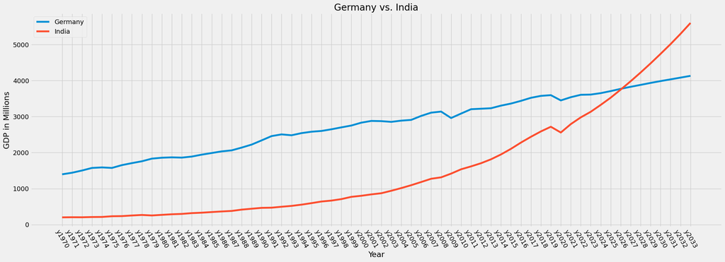

```python
plt.figure(figsize = (24,8)) #Set Fig Size
plt.title("Germany vs. India") #Set Title
plt.xlabel("Year") #Set XLabel
plt.ylabel("GDP in Millions") #Set YLabel
plt.xticks(rotation = 300) #Set Rotations
plt.plot(gdpValues.columns[1:], np.delete(gdpValues.loc[gdpValues["Country"] == "Germany"].values, 0)) #Graph Germany
plt.plot(gdpValues.columns[1:], np.delete(gdpValues.loc[gdpValues["Country"] == "India"].values, 0)) #Graph India
plt.legend(['Germany', 'India']) #Set Legend
plt.show() #Show Graph
```

### Key Takeaways:

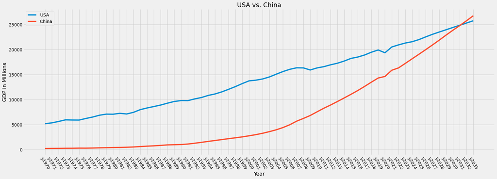

```python
plt.figure(figsize = (24,8))
plt.title("USA vs. China")
plt.xlabel("Year")
plt.ylabel("GDP in Millions")
plt.xticks(rotation = 300)
plt.plot(gdpValues.columns[1:], np.delete(gdpValues.loc[gdpValues["Country"] == "United States"].values, 0))
plt.plot(gdpValues.columns[1:], np.delete(gdpValues.loc[gdpValues["Country"] == "China"].values, 0))
plt.legend(['USA', 'China'])
plt.show()
```

### Key Takeaways:

As always, economics is sometimes considered king, and as Data Scientists we need to be looking at all trends, especially trens that can influence the future of the world. That being said, if you want to learn more about how China has accomplished this, and what it means for the future, [this is a great article](https://www.voanews.com/a/chinas-economy-could-overtake-us-economy-by-2030/6380892.html).

## **Question 3: What are the top 5 and lowest 5 country GDPs each year from 1970 - 2033?**

### Code Explanation and Items of Note:

Here, first we create a list called *yearList* which contains every year, using the argument from above to extract the years which are the column names from 1 to the end (with 0 being a label), ahd this time we conver it to a numpy array. We also create a empty list called top5List.

After that, we are using a loop that for each year element that is in yearList from 0 to the end of the list, it will go in and store in a variable called *currentTop5* the top 5 countries for that year. This is done in a very similar way to how we did it in problem 1, minus this time, instead of passing in a specific year, we go year by year by incrementing up the yearList and storing the .head(5) or top 5 for that year in this variable.

After this, we append the top5 for each year in the afformentioned *top5* list by appending in a nested list or a list inside of a list. For each nested list, we take the year (using the *replace* method to take the string and remove the y from it*, and the extracted top 5 countries from the head function, with the country column of each head function being extracted, converted to a numpy array, and then having the top 5 extracted manually 1-5 through list comprehension.

After the loop terminates, we create a new dataframe called *top5DF* and use the *pd.DataFrame* method with the list passed in to conver it to a dataframe for much more cleaner displaying, also using the *transpose* method of dataframes to have it neatly print side by side year after year.

### Key Findings:

I found it very interesting to see how much difference time can make when it comes to the rapidly changing economies of our world. Although the United States is consistently on top until our predicted timefrine established above, the United Kingdom and France used to be on the list, and Japan and Germany were 2 and three respectively. Then in our modern era Japan and Germany are knocked down by China and the United Kingdom and France are no where to be seen with India now being number 5.

It is definetly very interesting to view these trends and see how things shape up over-time in the coming years and decades.

```python
yearList = gdpValues.columns[1:].to_numpy()
top5List = []
for i in range(len(yearList)):
    currentTop5 = gdpValues[["Country", yearList[i]]].sort_values(by=yearList[i], ascending=False).head(5)
    top5List.append([yearList[i].replace('y', ''), currentTop5["Country"].to_numpy()[0], currentTop5["Country"].to_numpy()[1], currentTop5["Country"].to_numpy()[2], currentTop5["Country"].to_numpy()[3], currentTop5["Country"].to_numpy()[4]])
top5DF = pd.DataFrame(top5List).transpose()
top5DF
```

|  | 0 | 1 | 2 | 3 | 4 | 5 | 6 | 7 | 8 | 9 | ... | 54 | 55 | 56 | 57 | 58 | 59 | 60 | 61 | 62 | 63 |
| --- | --- | --- | --- | --- | --- | --- | --- | --- | --- | --- | --- | --- | --- | --- | --- | --- | --- | --- | --- | --- | --- |
| 0 | 1970 | 1971 | 1972 | 1973 | 1974 | 1975 | 1976 | 1977 | 1978 | 1979 | ... | 2024 | 2025 | 2026 | 2027 | 2028 | 2029 | 2030 | 2031 | 2032 | 2033 |
| 1 | United States | United States | United States | United States | United States | United States | United States | United States | United States | United States | ... | United States | United States | United States | United States | United States | United States | United States | United States | China | China |
| 2 | Japan | Japan | Japan | Japan | Japan | Japan | Japan | Japan | Japan | Japan | ... | China | China | China | China | China | China | China | China | United States | United States |
| 3 | Germany | Germany | Germany | Germany | Germany | Germany | Germany | Germany | Germany | Germany | ... | Japan | Japan | Japan | Japan | Japan | Japan | Japan | India | India | India |
| 4 | United Kingdom | United Kingdom | United Kingdom | United Kingdom | United Kingdom | United Kingdom | United Kingdom | United Kingdom | United Kingdom | United Kingdom | ... | Germany | Germany | Germany | India | India | India | India | Japan | Japan | Japan |
| 5 | France | France | France | France | France | France | France | France | France | France | ... | India | India | India | Germany | Germany | Germany | Germany | Germany | Germany | Germany |

6 rows × 64 columns

### Code Explanation and Items of Note:

In terms of the above explanation, a lot of key items of the code are the same with minute changes here and there. For one, the yearList can be borrwed but a new list called *bottom5List* is created. It is empty for now, but it will later be converted into a dataframe. Othe rthen everything else is the sale except this time, instead of using the head and then extracting the country names in the top 5 from it, we are using the tail to extract the bottom 5 country names. One key difference being this time instead of extracting the top 5 from the topmost or first to the 4th or last element of the arrays, we start at 4 and work back down since this time the first value of the tail is not the lowest, it would be the last value.

### Key Findings:

```python
bottom5List = []
for i in range(len(yearList)):
    currentBottom5 = gdpValues[["Country", yearList[i]]].sort_values(by=yearList[i], ascending=False).tail(5)
    bottom5List.append([yearList[i].replace('y', ''), currentBottom5["Country"].to_numpy()[4], currentBottom5["Country"].to_numpy()[3], currentBottom5["Country"].to_numpy()[2], currentBottom5["Country"].to_numpy()[1], currentBottom5["Country"].to_numpy()[0]])
bottom5DF = pd.DataFrame(bottom5List).transpose()
bottom5DF
```

|  | 0 | 1 | 2 | 3 | 4 | 5 | 6 | 7 | 8 | 9 | ... | 54 | 55 | 56 | 57 | 58 | 59 | 60 | 61 | 62 | 63 |
| --- | --- | --- | --- | --- | --- | --- | --- | --- | --- | --- | --- | --- | --- | --- | --- | --- | --- | --- | --- | --- | --- |
| 0 | 1970 | 1971 | 1972 | 1973 | 1974 | 1975 | 1976 | 1977 | 1978 | 1979 | ... | 2024 | 2025 | 2026 | 2027 | 2028 | 2029 | 2030 | 2031 | 2032 | 2033 |
| 1 | Yemen | Yemen | Bahrain | St. Lucia | Yemen | Yemen | St. Lucia | Namibia | Yemen | Bulgaria | ... | São Tomé and Principe | São Tomé and Principe | São Tomé and Principe | São Tomé and Principe | São Tomé and Principe | São Tomé and Principe | São Tomé and Principe | Tonga | Tonga | Tonga |
| 2 | Cyprus | Maldives | Maldives | Cyprus | St. Kitts Nevis | Maldives | Afghanistan | Laos | Libya | Bhutan | ... | Tonga | Tonga | Tonga | Tonga | Tonga | Tonga | Tonga | São Tomé and Principe | São Tomé and Principe | São Tomé and Principe |
| 3 | Bahrain | Dominica | Ethiopia | Barbados | Vanuatu | Ethiopia | St. Kitts Nevis | Afghanistan | Afghanistan | Maldives | ... | Dominica | Dominica | Dominica | Dominica | Dominica | Dominica | Dominica | Dominica | Dominica | Dominica |
| 4 | Bhutan | Grenada | Bhutan | Bhutan | Ethiopia | Bulgaria | Bulgaria | Ethiopia | Qatar | Qatar | ... | Samoa | Samoa | Samoa | Samoa | Samoa | Samoa | Samoa | Samoa | Samoa | Samoa |
| 5 | Barbados | St. Kitts Nevis | Afghanistan | Bahrain | Cyprus | Bhutan | Dominica | Maldives | Laos | Namibia | ... | St. Vincent Grenadines | St. Vincent Grenadines | St. Vincent Grenadines | St. Vincent Grenadines | St. Vincent Grenadines | St. Vincent Grenadines | St. Vincent Grenadines | St. Vincent Grenadines | St. Vincent Grenadines | St. Vincent Grenadines |

6 rows × 64 columns

### Code Explanation and Items of Note:

Like the previous problem, this problem starts by extracting a certain column from the dataframe and converting it to a numpy array. This time, we make use of the country column. After that, we make use of the ability of dataframes and Numpy Arrays to handle vector mathamatics and diretly subtract all values for every country between 2023 and 2000, converting the difference to numpy. After that, we join the list of countries with the list in difference of GDP for each country, conver it to a dataframe, sort it (with *1* refering to the values present) and printing out the head and tail (which print out the top and bottom 5).

### Key Takeaways:

```python
countryList = gdpValues["Country"].to_numpy()
gdpDifferenceList = gdpValues["y2023"]- gdpValues["y2000"].to_numpy()

jointList = [countryList, gdpDifferenceList]
jointListDF = pd.DataFrame(jointList).transpose()
jointListDF = jointListDF.sort_values(by=1, ascending=False)
print(jointListDF.head())
print(jointListDF.tail())
```

```
                  0         1
83            China  14480.44
1     United States   7561.93
101           India   2332.55
86            Korea    957.81
50   United Kingdom    873.48
               0       1
114        Tonga    0.08
19   Puerto Rico   -2.78
127        Syria   -3.02
129        Yemen  -19.69
35     Venezuela -179.45
```

## **Question 5: Is the saying that when the the US sneezes, the world catches a cold true?**

There is an old saying in the world of economics. [When the US Sneezes, the world catches a cold](https://theculturetrip.com/north-america/usa/articles/where-does-the-phrase-when-america-sneezes-the-world-catches-cold-originate). Howerver, is this still true in our modern era? Let's take a look at how the US still influences the world economy.

### Code Explanation and Items of Note:

Firstly, to make our lives easier, let us import in the full dataset again that includes the parts we ommited during cleanup, though renaming it as we only need it for select uses.

```python
gdpValuesRegions = pd.read_csv("RealGDPValues.csv", skiprows = 12, encoding='ISO-8859-1')
gdpValuesRegions
```

|  | Country | y1970 | y1971 | y1972 | y1973 | y1974 | y1975 | y1976 | y1977 | y1978 | ... | y2024 | y2025 | y2026 | y2027 | y2028 | y2029 | y2030 | y2031 | y2032 | y2033 |
| --- | --- | --- | --- | --- | --- | --- | --- | --- | --- | --- | --- | --- | --- | --- | --- | --- | --- | --- | --- | --- | --- |
| 0 | World | 18031.32 | 18886.63 | 19912.01 | 21199.60 | 21646.02 | 21799.32 | 22928.95 | 23872.10 | 24829.05 | ... | 93574.38 | 96339.12 | 99246.98 | 102149.56 | 105035.87 | 107976.13 | 110899.56 | 113783.41 | 116762.14 | 119839.41 |
| 1 | World less USA | 12842.95 | 13527.39 | 14270.94 | 15240.05 | 15718.68 | 15884.16 | 16695.07 | 17349.96 | 17945.89 | ... | 71997.94 | 74337.59 | 76703.30 | 79087.36 | 81512.44 | 84005.75 | 86473.73 | 88917.93 | 91449.07 | 94070.71 |
| 2 | United States and Canada | 5610.77 | 5798.42 | 6104.45 | 6454.60 | 6438.63 | 6433.92 | 6783.14 | 7090.28 | 7472.23 | ... | 23363.32 | 23822.74 | 24401.02 | 24954.81 | 25450.12 | 25929.82 | 26416.61 | 26890.12 | 27372.12 | 27862.76 |
| 3 | Canada | 422.41 | 439.18 | 463.38 | 495.05 | 511.29 | 518.76 | 549.26 | 568.15 | 589.07 | ... | 1786.89 | 1821.21 | 1857.33 | 1892.62 | 1926.69 | 1959.44 | 1990.79 | 2024.63 | 2059.05 | 2094.06 |
| 4 | United States | 5188.36 | 5359.23 | 5641.07 | 5959.55 | 5927.34 | 5915.16 | 6233.88 | 6522.14 | 6883.16 | ... | 21576.43 | 22001.53 | 22543.69 | 23062.19 | 23523.44 | 23970.38 | 24425.82 | 24865.49 | 25313.06 | 25768.70 |
| ... | ... | ... | ... | ... | ... | ... | ... | ... | ... | ... | ... | ... | ... | ... | ... | ... | ... | ... | ... | ... | ... |
| 227 | USMCA/8 | 5883.02 | 6080.90 | 6410.18 | 6784.37 | 6787.44 | 6802.77 | 7168.28 | 7488.49 | 7906.10 | ... | 24664.72 | 25153.86 | 25761.17 | 26344.89 | 26870.78 | 27381.74 | 27900.47 | 28408.10 | 28925.02 | 29451.37 |
| 228 | Europe and Central Asia/9 | 7308.57 | 7664.08 | 8005.14 | 8506.75 | 8720.52 | 8700.13 | 9091.03 | 9381.48 | 9700.40 | ... | 22100.40 | 22503.78 | 22898.20 | 23279.30 | 23651.64 | 24025.13 | 24393.46 | 24744.19 | 25100.99 | 25464.03 |
| 229 | Middle East and North Africa/10 | 656.43 | 726.18 | 825.21 | 901.50 | 976.96 | 970.15 | 1095.63 | 1139.91 | 1110.88 | ... | 4939.36 | 5098.38 | 5243.96 | 5395.11 | 5550.94 | 5707.07 | 5863.06 | 6029.28 | 6200.49 | 6376.84 |
| 230 | Other Southeast Asia outlook/11 | 125.43 | 132.59 | 139.47 | 150.81 | 157.53 | 164.17 | 180.12 | 195.00 | 207.45 | ... | 1681.35 | 1765.17 | 1850.05 | 1935.66 | 2022.98 | 2112.44 | 2203.41 | 2297.07 | 2394.93 | 2497.20 |
| 231 | Other South America outlook/12 | 168.01 | 177.61 | 183.69 | 189.40 | 200.16 | 200.82 | 208.02 | 216.86 | 226.97 | ... | 1035.45 | 1067.13 | 1103.02 | 1140.29 | 1178.78 | 1218.50 | 1259.49 | 1301.15 | 1344.20 | 1388.68 |

232 rows × 65 columns

From here, the rest of the code is pretty simple. Like previous problems we set the *figsize* to our standard as-well-as setting a title, xlabel, ylabel, and graph key as-well-as rotation for the years variables. After that, we are ploting the World GDP vs the World without the USA GDP on a second line.

[figure not shown]

```python
plt.figure(figsize = (24,8))
plt.title("USA vs. Rest of the World")
plt.xlabel("Year")
plt.ylabel("GDP in Millions")
plt.xticks(rotation = 300)
plt.plot(gdpValuesRegions.columns[1:], np.delete(gdpValuesRegions.loc[gdpValuesRegions["Country"] == "World"].values, 0))
plt.plot(gdpValuesRegions.columns[1:], np.delete(gdpValuesRegions.loc[gdpValuesRegions["Country"] == "World less USA"].values, 0))
plt.legend(["USA", "Rest of the World"])
plt.show()
```

### Key Takeaways:

I think it is safe to sy that the World Economy is somewhat reliant on the United States. We see how the trend line overall follows the dips that the US takes, and for that reason I am fairly certain that the world economy is reliant on the United States. Ignoring the 2020 dip if you wanted to argue that was a global dip due to COVID, even during the the 2008 financial crisis in the USA, we also saw the world see a decline in GDP.

That being said, it is important to acknowledge that there are likely counter-arguments to this argument such that the world economy is so interconnected, obviously it is the world influencing the US markets. That is a fair crtiscism that I acknowledge, but I feel the figure used to answer the next question will also help me double back down on my support for the saying.

## **Question 6: Was the new century growth of China really that unprecedented?**

I think one of the key themes that we keep seeing in the data analysis of this data is the unprecedented growth that China has sesen at the start of the current centuary. Yet, compared to the growth of the rest of the world, was it really all that unprecedented or was it fairly consistent with the rest of the world?

### Code Explanation and Items of Note:

Firstly, to make our lives easier, let us import in the full dataset again that includes the parts we ommited during cleanup, though renaming it as we only need it for select uses.

```python
growthRatesRegions = pd.read_csv("GrwothRate.csv", encoding='ISO-8859-1')
growthRatesRegions
```

|  | Country | g1971 | g1972 | g1973 | g1974 | g1975 | g1976 | g1977 | g1978 | g1979 | ... | g2024 | g2025 | g2026 | g2027 | g2028 | g2029 | g2030 | g2031 | g2032 | g2033 |
| --- | --- | --- | --- | --- | --- | --- | --- | --- | --- | --- | --- | --- | --- | --- | --- | --- | --- | --- | --- | --- | --- |
| 0 | World | 4.74 | 5.43 | 6.47 | 2.11 | 0.71 | 5.18 | 4.11 | 4.01 | 4.42 | ... | 2.66 | 2.95 | 3.02 | 2.92 | 2.83 | 2.80 | 2.71 | 2.60 | 2.62 | 2.64 |
| 1 | World less USA | 5.33 | 5.50 | 6.79 | 3.14 | 1.05 | 5.11 | 3.92 | 3.43 | 4.90 | ... | 3.10 | 3.25 | 3.18 | 3.11 | 3.07 | 3.06 | 2.94 | 2.83 | 2.85 | 2.87 |
| 2 | United States and Canada | 3.34 | 5.28 | 5.74 | -0.25 | -0.07 | 5.43 | 4.53 | 5.39 | 3.21 | ... | 1.27 | 1.97 | 2.43 | 2.27 | 1.98 | 1.88 | 1.88 | 1.79 | 1.79 | 1.79 |
| 3 | Canada | 3.97 | 5.51 | 6.84 | 3.28 | 1.46 | 5.88 | 3.44 | 3.68 | 3.71 | ... | 1.65 | 1.92 | 1.98 | 1.90 | 1.80 | 1.70 | 1.60 | 1.70 | 1.70 | 1.70 |
| 4 | United States | 3.29 | 5.26 | 5.65 | -0.54 | -0.21 | 5.39 | 4.62 | 5.54 | 3.17 | ... | 1.24 | 1.97 | 2.46 | 2.30 | 2.00 | 1.90 | 1.90 | 1.80 | 1.80 | 1.80 |
| ... | ... | ... | ... | ... | ... | ... | ... | ... | ... | ... | ... | ... | ... | ... | ... | ... | ... | ... | ... | ... | ... |
| 227 | USMCA/8 | 3.36 | 5.41 | 5.84 | 0.05 | 0.23 | 5.37 | 4.47 | 5.58 | 3.57 | ... | 1.31 | 1.98 | 2.41 | 2.27 | 2.00 | 1.90 | 1.89 | 1.82 | 1.82 | 1.82 |
| 228 | Europe and Central Asia/9 | 4.86 | 4.45 | 6.27 | 2.51 | -0.23 | 4.49 | 3.19 | 3.40 | 3.76 | ... | 1.31 | 1.83 | 1.75 | 1.66 | 1.60 | 1.58 | 1.53 | 1.44 | 1.44 | 1.45 |
| 229 | Middle East and North Africa/10 | 10.63 | 13.64 | 9.25 | 8.37 | -0.70 | 12.93 | 4.04 | -2.55 | 10.65 | ... | 3.10 | 3.22 | 2.86 | 2.88 | 2.89 | 2.81 | 2.73 | 2.84 | 2.84 | 2.84 |
| 230 | Other Southeast Asia outlook/11 | 5.71 | 5.19 | 8.13 | 4.46 | 4.21 | 9.72 | 8.26 | 6.39 | 6.35 | ... | 5.08 | 4.99 | 4.81 | 4.63 | 4.51 | 4.42 | 4.31 | 4.25 | 4.26 | 4.27 |
| 231 | Other South America outlook/12 | 5.72 | 3.42 | 3.11 | 5.68 | 0.33 | 3.58 | 4.25 | 4.66 | 5.71 | ... | 2.36 | 3.06 | 3.36 | 3.38 | 3.38 | 3.37 | 3.36 | 3.31 | 3.31 | 3.31 |

232 rows × 64 columns

From here, the rest of the code is pretty simple. Like previous problems we set the *figsize* to our standard as-well-as setting a title, xlabel, ylabel, and graph key as-well-as rotation for the years variables. Following that we will plot the growth rates of the World Without the USA, China, and the USA for comparision. There is one key difference this time that must be noted howerver, and that being that every array and extracted array for these plot statments are restricted to the values fom 30:54. This is to ensure that we are not looking at Growth Rates from 1971-1999 and also not the predicted Growth Rates as they always have a chance of being inconsistent or inaccurate, and thus can take away from the overall quality of the claim being made.

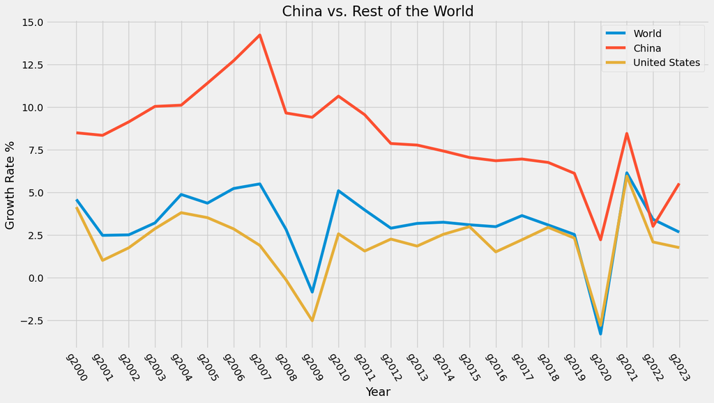

```python
plt.figure(figsize = (15,8))
plt.title("China vs. Rest of the World")
plt.xlabel("Year")
plt.ylabel("Growth Rate %")
plt.xticks(rotation = 300)
plt.plot(growthRatesRegions.columns[30:54], growthRatesRegions.loc[growthRatesRegions["Country"] == "World less USA"].values[0][30:54])
plt.plot(growthRatesRegions.columns[30:54], growthRatesRegions.loc[growthRatesRegions["Country"] == "China"].values[0][30:54])
plt.plot(growthRatesRegions.columns[30:54], growthRatesRegions.loc[growthRatesRegions["Country"] == "United States"].values[0][30:54])
plt.legend(["World", "China", "United States"])
plt.show()
```

### **Key Takeaways**:

To also use this visualization to reinforce my belief in the previous problem, I believe this graph also shows the power the USA has on the rest of the world economy because during the 2008 financial crisis when the US growth rate crated the groth rate of the world also cratered. Although it may not be a direct 1:1 correlation, I feel it is also possible to argue that there s that link.

## **Question 7: How do multiple countries of choice compare in GDP or Growth Rate?**

This problem was more of a implementation of previous coding knowledge with new ones rather then something that answers an actual question, though I encourage you to take a look for yourself and try the code.

### Code Explanation and Items of Note:

Firstly, I print out the values of the entire country column for the user, then I prompt the user to select how many countries they want to select. I meanwhile initalize two empty variables, oneList to hold the countries they select and a strong that will be useful for the title.

Once they make their selection I loop as many times as they requested, adding the country they requested to the list and appending it to the back of the string I created so it may be used for a title.

After that, the user is prompted to choose between GDP or Growth Rate as a graph type, with the key graph details as seen in above problems set such as the size, the xticks, the title, and the xlabel. They key difference this time being the title is dynamic based on the ammount of countries the user chooses.

After that, based on wether the user selected GDP or Growth Rate it sets the yLabel to the appropriete version that we care about and then plots the values as we have done previously.

```
['Canada' 'United States' 'Mexico' 'Antigua and Barbuda' 'Bahamas'
 'Barbados' 'Belize' 'Costa Rica' 'Cuba' 'Dominica' 'Dominican Republic'
 'El Salvador' 'Grenada' 'Guatemala' 'Haiti' 'Honduras' 'Jamaica'
 'Nicaragua' 'Panama' 'Puerto Rico' 'St. Kitts Nevis' 'St. Lucia'
 'St. Vincent Grenadines' 'Trinidad and Tobago' 'Argentina' 'Brazil'
 'Bolivia' 'Chile' 'Colombia' 'Ecuador' 'Guyana' 'Paraguay' 'Peru'
 'Suriname' 'Uruguay' 'Venezuela' 'Austria' 'Belgium' 'Denmark' 'Finland'
 'France' 'Germany' 'Greece' 'Ireland' 'Italy' 'Luxembourg' 'Netherlands'
 'Portugal' 'Spain' 'Sweden' 'United Kingdom' 'Bulgaria' 'Croatia'
 'Cyprus' 'Czech Republic' 'Estonia' 'Hungary' 'Latvia' 'Lithuania'
 'Malta' 'Poland' 'Romania' 'Slovakia' 'Slovenia' 'Iceland' 'Norway'
 'Switzerland' 'Albania' 'Bosnia and Herzegovina' 'Macedonia, North'
 'Serbia' 'Russia' 'Ukraine' 'Armenia' 'Azerbaijan' 'Belarus' 'Georgia'
 'Kazakhstan' 'Kyrgyzstan' 'Moldova' 'Tajikistan' 'Turkmenistan'
 'Uzbekistan' 'China' 'Hong Kong' 'Japan' 'Korea' 'Taiwan' 'Macau'
 'Mongolia' 'Cambodia' 'Indonesia' 'Malaysia' 'Myanmar' 'Philippines'
 'Thailand' 'Vietnam' 'Brunei' 'Laos' 'Singapore' 'Bangladesh' 'India'
 'Pakistan' 'Afghanistan' 'Bhutan' 'Nepal' 'Sri Lanka' 'Australia'
 'New Zealand' 'Fiji' 'Maldives' 'Papua New Guinea' 'Samoa'
 'Solomon Islands' 'Tonga' 'Vanuatu' 'Iran' 'Iraq' 'Saudi Arabia' 'Turkey'
 'Bahrain' 'Israel' 'Jordan' 'Kuwait' 'Lebanon' 'Oman' 'Qatar' 'Syria'
 'United Arab Emirates' 'Yemen' 'Egypt' 'Morocco' 'Algeria' 'Libya'
 'Tunisia' 'Nigeria' 'South Africa' 'Benin' 'Burkina Faso' 'Cabo Verde'
 "Côte d'Ivoire" 'Gambia' 'Ghana' 'Guinea' 'Guinea-Bissau' 'Liberia'
 'Mali' 'Niger' 'Senegal' 'Sierra Leone' 'Togo' 'Angola' 'Botswana'
 'Burundi' 'Cameroon' 'Central African Republic' 'Chad'
 'Democratic Republic of Congo' 'Djibouti' 'Equatorial Guinea' 'Eritrea'
 'Ethiopia' 'Gabon' 'Kenya' 'Lesotho' 'Madagascar' 'Malawi' 'Mauritania'
 'Mauritius' 'Mozambique' 'Namibia' 'Republic of Congo' 'Rwanda'
 'Seychelles' 'Sudan' 'Swaziland/Eswatini' 'São Tomé and Principe'
 'Tanzania' 'Uganda' 'Zambia' 'Zimbabwe']

Select Countries:
```

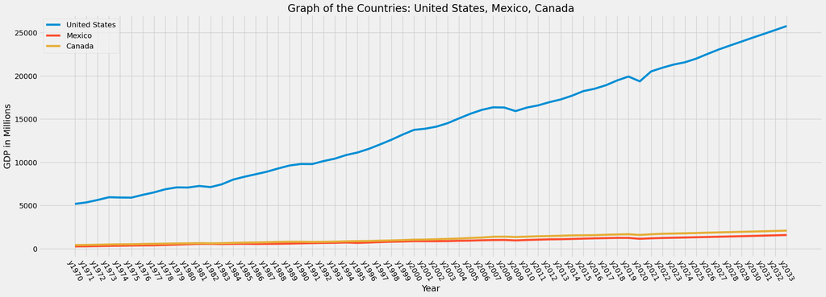

```python
print(growthRates["Country"].values)
print("\nSelect Countries:")

howMany = int(input("How many countries are you selecting?"))
countryList = []
countryStr = "Graph of the Countries:"

for i in range(howMany):
    country = input("Select Country")
    countryList.append(country)
    countryStr = countryStr + " " + country + ","

userChoice = input("\nGDP or Growth Rate?")
plt.figure(figsize = (24,8))
plt.xticks(rotation = 300)
plt.title(countryStr[:-1])
plt.xlabel("Year")

if userChoice == "GDP" or userChoice == "gdp":
    plt.ylabel("GDP in Millions")
    for i in range(len(countryList)):
        plt.plot(gdpValues.columns[1:], np.delete(gdpValues.loc[gdpValues["Country"] == countryList[i]].values, 0))
else:
    plt.ylabel("Growth Rate %")
    for i in range(len(countryList)):
        plt.plot(growthRates.columns[1:], np.delete(growthRates.loc[growthRates["Country"] == countryList[i]].values, 0))

plt.legend(countryList)
plt.show()
```

### Key-Takeaway:

The key takeway in this problem is to reinforce what I have been saying since the start. Anyone can do data analytics and see the overarching themes and paterns that are changing in the world. Have fun and try and see what themes you are able to locate!

## **Question 8: What are the Top and Bottom 5 in Growth Rate?**

Back to more traditional questions, this question aims to see what the Top and Bottom 5 countries were in Growth Rate. This is accomplished by taking the mean of each countries growth rate from the start. You may wonder, why mean? I choose mean as a indicator for this problem because I feel it is best equiped to show a countries average growth rate since the start rather then other stastical functions which may have been swayed by bad years or years of major growth. Mean is also effected by these, but it also takes into account the normal years where nothing of note is neccesarily happening.

### Code Explanation and Items of Note:

Firstly, I extract the the years of the growthList dataset and I export it to a numpy array. I also extract the list of all all country names, specifically its values, and store it in a list. I then iterate over the length of the length of a list of values of the country column to iterate over each county where I go and calculate the mean for each country, using previous techniques of list comprehension to overcome issues sorrounding the labels present in the data. I then apped the name of the country and the mean growth rate in a nested list like previous problems, converting it to a DataFrame and then sorting the values (as a refresher by column 1 which is the values) and then printing the head and tail.

### **Key Takeaways:**

It was very interesting to see that, when it was all said in done, the countries of Laos and Guinea actually had the highest growth even though you may not have considered them to be on this list as their GDPs were very small. It is also interesting to see Botswana and Iraq on the list for the same reason. Finally it is suprising to see China as only third after discusing its unparalled growth previously, though this is likely due to the fact that up until th 2000s China's Economy was not yet ramping up at the speed it had post 2000, and thus its mean growth rate is brought done by those days. Other then that, I see nothing too unebleivable in the bottom 5 growth rate, minus the fact that Venezuala managed to hang on to a barely positive mean growth rate even though its GDP had fallen so much compared to where it started, pointing to major economic fluctuation as a possible explanation.

```python
growthRateYearList = growthRates.columns[1:].to_numpy()
countryList = growthRates["Country"].values
meanGrowthRate = []
for i in range(len(growthRates["Country"].values)):
    currentMean = np.mean(growthRates.values[i][1:])
    meanGrowthRate.append([countryList[i], currentMean])

meanGrowthRateDF = pd.DataFrame(meanGrowthRate)
meanGrowthRateDF = meanGrowthRateDF.sort_values(by=1, ascending=False)
print(meanGrowthRateDF.head())
print(meanGrowthRateDF.tail())
```

```
                     0          1
98                Laos  11.595873
159  Equatorial Guinea   9.503492
83               China   7.881270
152           Botswana   7.045873
117               Iraq   6.328254
            0         1
14      Haiti  1.357619
72    Ukraine  1.247778
16    Jamaica  1.182381
5    Barbados  1.176984
35  Venezuela  0.663651
```

## **Question 9: Is there an GDP gap in the world?**

Another interesting thing to consider, the Standard Deviation of the World GDPs over time. Now you may wonder, why is this interesting? Well as I had explained when we first started the project and I had used the *describe* function, it is interesting because it is able to see how much variance there is in the GDPs of the world compared to the mean GDP, aka is there a gdp gap between the countries of the world.

### Code Explanation and Items of Note:

Comparatively the code here is very simple. Here I quiete literally make use of the describe function for my gain, just extracting the *std* row, or the Standard Deviation row from the describe table and convert it to a numpy array. After that it is the standard graphicing procedures that I have been using in the course of the presentation.

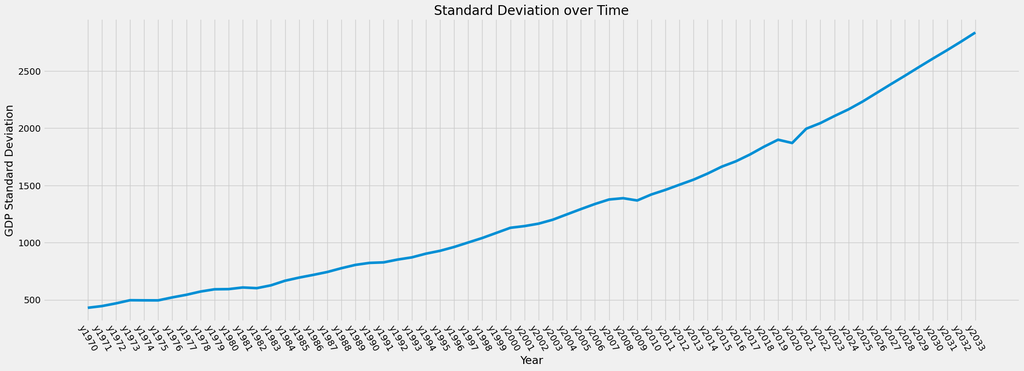

```python
stdArray = gdpValues.describe().loc["std"].to_numpy()

plt.figure(figsize = (24,8))
plt.xticks(rotation = 300)
plt.title("Standard Deviation over Time")
plt.xlabel("Year")
plt.ylabel("GDP Standard Deviation")
plt.plot(gdpValues.columns[1:], stdArray)
plt.show()
```

### **Key Takeaways:**

It is crazy to see overtime from 1970 to the future just how much the standard deviation has increased at the very crazy levels it has. Although we cannot takeaway from this graph which side of the income gap is causing the increse of standard deviation. The Standard Deviation works both ways, both above the mean and below the mean, and thus we are not able to say wether this is a income gap caused by countries that are unfortunatley having a worser economic situation or richer countries that keep getting richer and leaving the other countries in the dust.

## **Question 10: How does the growth of the various regions look over time?**

Finally, I wanted to just compare the GDPs and Growth Rates between the various regions to see economic trends based on a region by region basis.

### Code Explanation and Items of Note:

The Code in both cells is not that unfamilar at this point, though what is different this time is that I had to manually enter region data by using the gdpValuesRegion dataset from earlier which is the reloaded dataset with the region data included. For the North America region I had to add together the United States and Canada with the Mexico and Latin America "countries" or values. All the other ones were very straight forward. After that, I simply created a graph as I have throughout this project, and plotted eac region.

```python
northAmerica = gdpValuesRegions.loc[gdpValuesRegions["Country"] == "United States and Canada"].values + gdpValuesRegions.loc[gdpValuesRegions["Country"] == "Mexico"].values + gdpValuesRegions.loc[gdpValuesRegions["Country"] == "Latin America"].values
southAmerica = gdpValuesRegions.loc[gdpValuesRegions["Country"] == "South America"].values
europeRegion = gdpValuesRegions.loc[gdpValuesRegions["Country"] == "Europe"].values
asiaOceania = gdpValuesRegions.loc[gdpValuesRegions["Country"] == "Asia and Oceania"].values
africaRegion = gdpValuesRegions.loc[gdpValuesRegions["Country"] == "Africa"].values
```

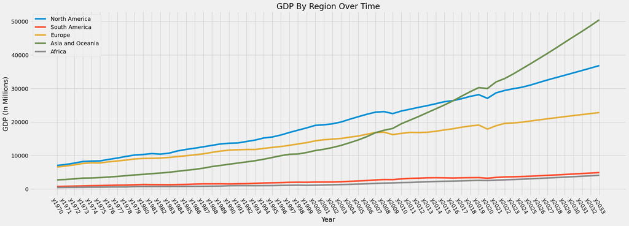

```python
plt.figure(figsize = (24,8))
plt.xticks(rotation = 300)
plt.title("GDP By Region Over Time")
plt.xlabel("Year")
plt.ylabel("GDP (In Millions)")
plt.plot(gdpValues.columns[1:], northAmerica[0][1:])
plt.plot(gdpValues.columns[1:], southAmerica[0][1:])
plt.plot(gdpValues.columns[1:], europeRegion[0][1:])
plt.plot(gdpValues.columns[1:], asiaOceania[0][1:])
plt.plot(gdpValues.columns[1:], africaRegion[0][1:])
plt.legend(["North America", "South America", "Europe", "Asia and Oceania", "Africa"])
plt.show()
```

### **Key Takeaways:**

As we see above we see three very interesting trends on this graph when it comes to GDP values overtime. Firstly, we see that of Africa and South America which has been on the rise but has almost been a very linear and flat increase when compared to the rest of the world, with both starting in the same place. We also see how North America and Europe have started in a very similar place as-well, but overtime North America has increased at a slightly faster rate then Europe which seems to have stagnated ever so slightly. Then we see the trend of Asia, which started off well below North America and Europe and then it passesd Europe in 2008 and North America in 2016. Its trend line is additonally at a much steeper incline then that of any other line in the graph which will show its consistent and rapid increase past the other regions possibly in the future.

### Code Explanation and Items of Note:

Once again, everything is very similar to above, with the only difference being this area makes use of the growthRatesRegions dataset. Everything else is the same as the above problem.

```python
northAmerica = growthRatesRegions.loc[growthRatesRegions["Country"] == "United States and Canada"].values + growthRatesRegions.loc[growthRatesRegions["Country"] == "Mexico"].values + growthRatesRegions.loc[growthRatesRegions["Country"] == "Latin America"].values
southAmerica = growthRatesRegions.loc[growthRatesRegions["Country"] == "South America"].values
europeRegion = growthRatesRegions.loc[growthRatesRegions["Country"] == "Europe"].values
asiaOceania = growthRatesRegions.loc[growthRatesRegions["Country"] == "Asia and Oceania"].values
africaRegion = growthRatesRegions.loc[growthRatesRegions["Country"] == "Africa"].values
```

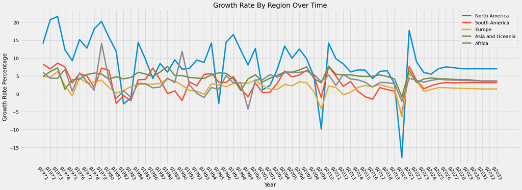

```python
plt.figure(figsize = (24,8))
plt.xticks(rotation = 300)
plt.title("Growth Rate By Region Over Time")
plt.xlabel("Year")
plt.ylabel("Growth Rate Percentage")
plt.plot(growthRatesRegions.columns[1:], northAmerica[0][1:])
plt.plot(growthRatesRegions.columns[1:], southAmerica[0][1:])
plt.plot(growthRatesRegions.columns[1:], europeRegion[0][1:])
plt.plot(growthRatesRegions.columns[1:], asiaOceania[0][1:])
plt.plot(growthRatesRegions.columns[1:], africaRegion[0][1:])
plt.legend(["North America", "South America", "Europe", "Asia and Oceania", "Africa"])
plt.show()
```

### **Key Takeaways:**

# Thank You for Your Time in Reading this Project, Have a Good Day!